# Lista 2 - Dropout e Keras

Matheus Stivali

21/09/2021

# Introdução

Este trabalho tem o objetivo de incluir a técnica de regularização *dropout* rede neural implementada na Lista 1. Adicionalmente essa rede neural que foi implementada “na mão” na Lista 1 será implementada pelo pacote keras.

Na lista 1 o algoritmo de *backpropagation* foi implemnetado de forma errada (fazendo elemento a elemento), nesta versão do código isso foi corrigido para incorporar o cálculo matricial.

O processo gerador de dados “real” que se busca identificar e estimar é dado por:

$$Y \sim N(\mu,\sigma = 1) \\
\mu = |X_{1}^{3} - 30 \times sen(X_{2}) + 10| \\
X_{j} \sim \text{Uniforme(-3,3); j=1,2.}$$
O código abaixo gera esses dados, armazenado no objetos `dados`, e já os divide em conjunto de treinamento e de teste.

```r
##########################################################################
### Gerando dados "observados"
##########################################################################
set.seed(2.2020)
m.obs <- 100000
dados <- tibble(x1.obs=runif(m.obs, -3, 3),
                x2.obs=runif(m.obs, -3, 3)) %>%
  mutate(mu=abs(x1.obs^3 - 30*sin(x2.obs) + 10),
         y=rnorm(m.obs, mean=mu, sd=1))

##########################################################################
## Divisão do conjunto de dados
##########################################################################
X_trein <- as.matrix(dados[1:80000,1:2])
X_teste <- as.matrix(dados[80001:100000,1:2])
Y_trein <- as.matrix(dados[1:80000,4])
Y_teste <- as.matrix(dados[80001:100000,4])
```

A rede neural que se quer ajustar tem uma camada escondida contendo dois neurônios, podendo ser descrita por:

$$\text{Camada escondida:} \\
h_1 = \phi(x_1w_1+x_2w_3 + b_1) = \phi(a_1) \\
h_2 = \phi(x_1w_2+x_2w_4 + b_2) = \phi(a_2) \\
\text{Camada de saída:} \\
\hat{y} = h_1w_5+h_2w_6 + b_3$$
Ou então, matricialmente (os subscritos indicam as dimensões das matrizes):

$$\underbrace{
y_{1,n} =
\begin{bmatrix}
y_{1} \\
y_{2} \\
\ldots
\end{bmatrix}}_{\text{Dados observados}}
;\hspace{5pt}
\underbrace{
X_{2,n} =
\begin{bmatrix}
x_{1,1} & x_{1,2} \\
x_{2,1} & x_{2,2} \\
\ldots & \ldots
\end{bmatrix}}_{\text{Matrix Design}}
;\hspace{5pt}
\underbrace{
\theta_{1,9}^T = (w_1, w_2, w_3, w_4, w_5, w_6, b_1, b_2, b_3)
}_{\text{Vetor de pesos}} \\
\underbrace{
W^{(1)}_{2,2} =
\begin{bmatrix}
w_{1} & w_{2} \\
w_{3} & w_{4}
\end{bmatrix}}_{\text{Pesos da 1ª camada}}
;\hspace{5pt}
\underbrace{
b^{(1)}_{2,1} =
\begin{bmatrix}
b_{1} \\
b_{2}
\end{bmatrix}}_{\text{Vieses da 1ª camada}}
;\hspace{5pt}
\underbrace{
W^{(2)}_{1,2} =
\begin{bmatrix}
w_{5} \\
w_{6}
\end{bmatrix}}_{\text{Pesos da 2ª camada}}
;\hspace{5pt}
\underbrace{
b^{(2)}_{1,1} =
b_{3}}_{\text{Viés da 2ª camada}}
;\hspace{5pt}
\underbrace{
\phi(x) = \dfrac{1}{1+e^{-x}}
}_{\text{Função de ativação}}\\
h_{2,1} = \phi ( XW^{(1)}+ [b^{(1) T}] ) = \phi(a_{2,1}) =
\underbrace{
\begin{bmatrix}
h_{1,1} & h_{1,2} \\
h_{2,1} & h_{2,2} \\
\ldots & \ldots
\end{bmatrix}_{n,2}}_{\text{Resultado da 1ª camada}} \\
\hat{y}_{n,1} = h W^{(2)} + [b_{3}]_{n,1} =
\underbrace{
\begin{bmatrix}
\hat{y}_{1} \\
\hat{y}_{2} \\
\ldots
\end{bmatrix}_{n,1}}_{\text{Saída}} \\$$

Isto é, os dados de input da *matriz design* ($x_{i,1}$ e $x_{i,2}$) são transformados na primeira camada pela aplicação em sequência de uma transormação linear ($W^{(1)}$) e de uma transformação não linear $\phi(.)$. Onde $\phi(.)$ é a função de ativação logística: $\phi(x) = \dfrac{1}{1+e^{-x}}$ Finalmente, os resultados da camada escondida são levados a camada de saída por uma outra transformação linear ($W^{(2)}$). Cada transformação linear é acompanhada da soma dos viéses ($b^{(1)}$ e $b^{(2)}$, respectivamente).

A função custo que se adotou para esta rede é:

$$J(\theta) = \dfrac{1}{m} \sum^{m}_{i=1}L(f(x_{1,i},x_{2,i}),y_i) = \dfrac{\sum^{m}_{i=1}(y_i - \hat{y}_i)^2}{m}$$

A implementação da Lista 1 é apresentada abaixo:

```r
##########################################################################
## Definindo os valores:
##########################################################################
X <- X_trein
Y <- Y_trein
theta_0 <- c(0.1, 0.1, 0.1, 0.1, 0.1, 0.1, 0.1, 0.1, 0.1)

##########################################################################
## Agrupando os componentes em uma lista
##########################################################################
componentes1 <- list(entrada = X,
                    observado = Y,
                    pesos_c1 = matrix(theta_0[1:4], nrow = 2, byrow = TRUE),
                    vies_c1 = matrix(theta_0[7:8], ncol = 2, nrow = dim(X)[1], byrow=TRUE),
                    pesos_cs = matrix(theta_0[5:6], nrow = 2, byrow = TRUE),
                    vies_cs = matrix(theta_0[9], ncol = 1, nrow = dim(Y)[1], byrow = TRUE),
                    camada_tl = matrix(rep(0,dim(X)[1]*dim(X)[2]),
                                       nrow=dim(X)[1], ncol=dim(X)[2],
                                       byrow = TRUE),
                    camada_tnl = matrix(rep(0,dim(X)[1]*dim(X)[2]),
                                        nrow=dim(X)[1], ncol=dim(X)[2],
                                        byrow = TRUE),
                    saida = matrix(rep(0,dim(Y)[1]), ncol=1)
                    )

#############################################
# Phi - função de ativação logística
#############################################
fih <- function(x) {
  1 / (1 + exp(-x))
  }

#############################################
# Phi_linha - derivada da função logística
#############################################
fih_linha <- function(x) {
 ( 1 / (1 + exp(-x)) ) * ( 1 - (1 / (1 + exp(-x))) )
 }

##########################################################################
## Função de previsão
##########################################################################
previsao <- function(rn) {
  rn$camada_tl <- (rn$entrada %*% rn$pesos_c1) + rn$vies_c1
  rn$camada_tnl <- fih(rn$camada_tl)
  rn$saida <- (rn$camada_tnl %*% rn$pesos_cs) + rn$vies_cs
  return(rn)
  }

##########################################################################
## Função de custo
##########################################################################
custo <- function(rn){
  mean((rn$observado - rn$saida)^2)
}
```

A correção em relação a lista 1 é o algorítmo de back-propagation, que agora foi feito da forma matricial:

```r
#############################################
# Função gradiente
#############################################
gradiente <- function(rn){
  gradi <- rep(0,9)

  g1 <- -2 / dim(rn$observado)[1] * (rn$observado - rn$saida)

     gradi[9] <- sum(g1)

  g2 <- g1 %*% t(rn$pesos_cs) * fih_linha(rn$camada_tl)

     gradi[7:8] <- colSums(g2)

     gradi[5:6] <- t(rn$camada_tnl) %*% g1

     gradi[1:4] <- t(t(rn$entrada) %*% g2)

  return(gradi)
}

componentes1 <- previsao(componentes1)
custo(componentes1)
```

```
## [1] 670.3107
```

```r
gradiente(componentes1)
```

```
## [1]  -0.1700960  -0.1700960   0.6357381   0.6357381 -22.3590539 -22.3590539
## [7]  -1.0746279  -1.0746279 -43.4700502
```

```r
#######################################################
## Parâmetros de inicialização
#######################################################
X <- X_trein
Y <- Y_trein
theta_0 <- c(0, 0, 0, 0, 0, 0, 0, 0, 0)

n <- 100 # Número de iterações
tx_aprendisagem <- 0.1

componentes1 <- list(entrada = X,
                    observado = Y,
                    pesos_c1 = matrix(theta_0[1:4], nrow = 2, byrow = TRUE),
                    vies_c1 = matrix(theta_0[7:8], ncol = 2, nrow = dim(X)[1], byrow=TRUE),
                    pesos_cs = matrix(theta_0[5:6], nrow = 2, byrow = TRUE),
                    vies_cs = matrix(theta_0[9], ncol = 1, nrow = dim(Y)[1], byrow = TRUE),
                    camada_tl = matrix(rep(0,dim(X)[1]*dim(X)[2]),
                                       nrow=dim(X)[1], ncol=dim(X)[2],
                                       byrow = TRUE),
                    camada_tnl = matrix(rep(0,dim(X)[1]*dim(X)[2]),
                                        nrow=dim(X)[1], ncol=dim(X)[2],
                                        byrow = TRUE),
                    saida = matrix(rep(0,dim(Y)[1]), ncol=1)
                    )

##############################################
## Log do custo ao longo das iterações
##############################################
custo_evol <- data.frame(
  iteracao = 1:n,
  cost = rep(0,n)
)
# Armazena os parâmetros de cada iteração
thetas <- data.frame()

##############################################
## Gradiente descendente
##############################################
for (i in seq_len(n)){
    # Estimativa
    componentes1 <- previsao(componentes1)
    # Cálculo do custo
    custo_evol$cost[i] <- custo(componentes1)
    # Atualização dos parâmetros
    thetas <- rbind(thetas, theta_0)
    theta_0 <- theta_0 - (tx_aprendisagem * gradiente(componentes1))
    componentes1$pesos_c1 <- matrix(theta_0[1:4], nrow = 2, byrow = TRUE)
    componentes1$vies_c1 <- matrix(theta_0[7:8], ncol = 2, nrow = dim(X_trein)[1], byrow=TRUE)
    componentes1$pesos_cs <- matrix(theta_0[5:6], nrow = 2, byrow = TRUE)
    componentes1$vies_cs <- matrix(theta_0[9], ncol = 1, nrow = dim(Y_trein)[1], byrow = TRUE)
  }

custo_evol[which.min(custo_evol$cost),]
```

```
##    iteracao     cost
## 19       19 145.0926
```

## 1. Dropout na camada de entrada e intermediária

A primeira tarefa deste trabalho é incluir uma regra de *dropout* na camada de entrada e intermediária da rede neural.

A técnica de dropout é uma técnica de regularização de redes neurais que visa evitar o sobre-ajustamento (overfitting) devido à chamada “co-adaptação” no treinamento das redes. A coadaptação corresponde a diferentes neurônios identificando as mesmas *features* e sendo em algum grau redundantes. Como aponta Lewis(2016, p.53) a coadaptação é um conceito próximo a multicolinearidade em regressão linear.

O dropout corresponde a desativar de forma aleatória alguns neurônios da rede durante o seu treinamento de forma que o processo de treinamento inclua as “sub-redes” derivadas da especificação original na definição dos pesos.

Aqui a implementação do dropout é realizada considerando duas *máscaras de dropout*, uma aplicada a camada de entrada e outra a camada escondida. A inclusão dessas máscaras é representada matricialmente abaixo.

$$d_{i,j} \sim Binomial(p)\\
D^{(1)}_{n,2} =
\underbrace{
\begin{bmatrix}
d_{1,1} & d_{1,2} \\
d_{2,1} & d_{2,2} \\
\ldots & \ldots
\end{bmatrix}_{n,2}}_{\text{Máscara de dropout da 1ª camada}}
\hspace{10pt}
D^{(2)}_{n,2} =
\underbrace{
\begin{bmatrix}
d_{1,1} & d_{1,2} \\
d_{2,1} & d_{2,2} \\
\ldots & \ldots
\end{bmatrix}_{n,2}}_{\text{Máscara de dropout da 2ª camada}} \\[15pt]$$

$$\text{Representação matricial com máscaras de dropout:} \\[15pt]
(X \odot D^{(1)} ) W^{(1)}+ [b^{(1) T}] = A \\
H = \phi(A) \\
\hat{Y} = (H \odot D^{(2)} ) W^{(2)}+ [b^{(2) T}] \\$$
Para implementar computacionalmente essa formulação com o dropout é necessário alterar tanto a função de previsão (feed-forward) quanto o gradiente da função custo que ajustará os pesos durante o treinamento da reda.

Quanto a função de previsão (`previsao_drop`) ela é ajustada para considerar as máscaras de dropout.

```r
##########################################################################
## Função de previsão com dropout
##########################################################################
previsao_drop <- function(rn) {
  rn$camada_tl <- ((rn$entrada*rn$D1) %*% rn$pesos_c1) + (rn$vies_c1*rn$D1)
  rn$camada_tnl <- fih(rn$camada_tl)
  rn$saida <- ((rn$camada_tnl*rn$D2) %*% rn$pesos_cs) + rn$vies_cs
  return(rn)
  }
```

Já a função gradiente tem que ser alterada porque as máscaras vão influenciar as derivadas.

$$\dfrac{\partial J(\theta)}{\partial \theta_j} =
\dfrac{-2}{m} \times \bigg( \mathbf{1}_{1,n} \times (Y - \hat{Y})_{n,1} \bigg) \times \bigg( \dfrac{\partial \hat{Y}}{\partial \theta} \bigg) \\
\dfrac{\partial \hat{Y}}{\partial W^{(1)}} =
\bigg( \underbrace{\dfrac{\partial H}{\partial W^{(1)}}}_{X \odot D^{(1)} \times \phi'(A)} \odot D^{(2)} \bigg) \times W^{(2)} = \bigg( X \odot D^{(1)} \times \phi'(A) \odot D^{(2)} \bigg) \times W^{(2)}\\
\dfrac{\partial \hat{Y}}{\partial b^{(1)}} =
\bigg( \underbrace{\dfrac{\partial H}{\partial b^{(1)}}}_{\phi'(A)} \odot D^{(2)} \bigg) \times W^{(2)} = \bigg( \phi'(A) \odot D^{(2)} \bigg) \times W^{(2)}\\
\dfrac{\partial \hat{Y}}{\partial W^{(2)}} = H \odot D^{(2)} = \phi(A) \odot D^{(2)}\\
\dfrac{\partial \hat{Y}}{\partial b^{(2)T}} = 1\\$$

```r
#############################################
# Função gradiente com dropout
#############################################
gradiente_drop <- function(rn){

  gradi <- rep(0,9)

  g1 <- -2 / dim(rn$observado)[1] * (rn$observado - rn$saida)

     gradi[9] <- sum(g1)

  g2 <- g1 %*% t(rn$pesos_cs) * (fih_linha(rn$camada_tl) * rn$D2)

     gradi[7:8] <- colSums(g2)

     gradi[5:6] <- t(rn$camada_tnl * rn$D2) %*% g1

     gradi[1:4] <- t(t(rn$entrada * rn$D1) %*% g2)

  return(gradi)
}
```

```r
#######################################################
## Parâmetros de inicialização
#######################################################
set.seed(092021)
X <- X_trein
Y <- Y_trein
theta_0 <- c(0.1, 0.1, 0.1, 0.1, 0.1, 0.1, 0.1, 0.1, 0.1)
prob_in = 0.6
n <- 100 # Número de iterações
tx_aprendisagem <- 0.1

componentes2 <- list(entrada = X,
                    observado = Y,
                    pesos_c1 = matrix(theta_0[1:4], nrow = 2, byrow = TRUE),
                    vies_c1 = matrix(theta_0[7:8], ncol = 2, nrow = dim(X)[1], byrow=TRUE),
                    D1 = matrix(rbinom(dim(X)[1]*dim(X)[2],1,prob_in), ncol=2, byrow=TRUE),
                    pesos_cs = matrix(theta_0[5:6], nrow = 2, byrow = TRUE),
                    vies_cs = matrix(theta_0[9], ncol = 1, nrow = dim(Y)[1], byrow = TRUE),
                    camada_tl = matrix(rep(0,dim(X)[1]*dim(X)[2]),
                                       nrow=dim(X)[1], ncol=dim(X)[2],
                                       byrow = TRUE),
                    camada_tnl = matrix(rep(0,dim(X)[1]*dim(X)[2]),
                                        nrow=dim(X)[1], ncol=dim(X)[2],
                                        byrow = TRUE),
                    D2 = matrix(rbinom(dim(X)[1]*dim(X)[2],1,prob_in), ncol=2, byrow=TRUE),
                    saida = matrix(rep(0,dim(Y)[1]), ncol=1)
                    )
```

O custo para essa rede é de `670.3107`

```r
rede_drop1 <- previsao(componentes2)
custo(rede_drop1)
```

```
## [1] 670.3107
```

E o processo de minimização via gradiente descendente em 100 iterações encontra um custo mínimo de `147.0218` na iteração **72**.

```r
##############################################
## Log do custo ao longo das iterações
##############################################
custo_evol_drop <- data.frame(
  iteracao = 1:n,
  cost = rep(0,n)
)
# Armazena os parâmetros de cada iteração
thetas <- data.frame()

##############################################
## Gradiente descendente
##############################################
for (i in seq_len(n)){
    # Estimativa
    componentes2 <- previsao_drop(componentes2)
    # Cálculo do custo
    custo_evol_drop$cost[i] <- custo(componentes2)
    # Atualização dos parâmetros
    thetas <- rbind(thetas, theta_0)
    theta_0 <- theta_0 - (tx_aprendisagem * gradiente_drop(componentes2))
    componentes2$pesos_c1 <- matrix(theta_0[1:4], nrow = 2, byrow = TRUE)
    componentes2$vies_c1 <- matrix(theta_0[7:8], ncol = 2, nrow = dim(X_trein)[1], byrow=TRUE)
    componentes2$pesos_cs <- matrix(theta_0[5:6], nrow = 2, byrow = TRUE)
    componentes2$vies_cs <- matrix(theta_0[9], ncol = 1, nrow = dim(Y_trein)[1], byrow = TRUE)
}

custo_evol[which.min(custo_evol_drop$cost),]
```

```
##    iteracao     cost
## 72       72 147.0218
```

## 2. Estimativa pontual e intervalar para $y_1$

Está seção obtem uma estimativa pontual e outra intervalar para o valor de $y_{T1}$, isto é, para a primeira observação do conjunto de teste.

Essas estimativas são obtidas a partir de 200 estimativas utilizando os pesos da rede treinada e a máscara de dropout.

```r
#######################################################
## Parâmetros de estimativas
#######################################################
X200 <- matrix(X_teste[1,], nrow = 200, ncol = 2, byrow = TRUE)
Y200 <- matrix(Y_teste[1,], nrow = 200, byrow = TRUE)

componentes3 <- list(entrada = X200,
                    observado = Y200,
                    pesos_c1 = componentes2$pesos_c1,
                    vies_c1 = componentes2$vies_c1[1:dim(X200)[1]],
                    D1 = componentes2$D1[1:dim(X200)[1]],
                    pesos_cs = componentes2$pesos_cs,
                    vies_cs = componentes2$vies_cs[1:dim(X200)[1]],
                    camada_tl = matrix(rep(0,dim(X200)[1]*dim(X200)[2]),
                                       nrow=dim(X200)[1], ncol=dim(X200)[2],
                                       byrow = TRUE),
                    camada_tnl = matrix(rep(0,dim(X200)[1]*dim(X200)[2]),
                                        nrow=dim(X200)[1], ncol=dim(X200)[2],
                                        byrow = TRUE),
                    D2 = componentes2$D2[1:dim(X200)[1]],
                    saida = matrix(rep(0,dim(X200)[1]), ncol=1)
                    )

y1_hat <- previsao_drop(componentes3)

mean(y1_hat$saida)
```

```
## [1] 20.93216
```

```r
quantile(y1_hat$saida, probs = c(0.025,0.975))
```

```
##     2.5%    97.5%
## 18.05749 27.33061
```

A estimativa pontual é de `20.93216`, com um IC de `[18.05749; 27.33061]`.

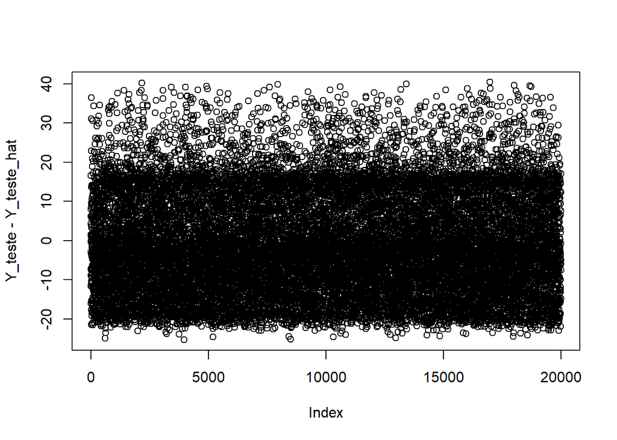

```r
Y_teste_hat = matrix(ncol = 1, nrow = 20000)

for (i in seq_len(dim(X_teste)[1])){

  X_loop <- matrix(X_teste[i,], nrow = 200, ncol = 2, byrow = TRUE)

  comp_loop <- list(entrada = X_loop,
                    pesos_c1 = componentes2$pesos_c1,
                    vies_c1 = componentes2$vies_c1[1:dim(X_loop)[1]],
                    D1 = componentes2$D1[1:dim(X_loop)[1]],
                    pesos_cs = componentes2$pesos_cs,
                    vies_cs = componentes2$vies_cs[1:dim(X_loop)[1]],
                    camada_tl = matrix(rep(0,dim(X_loop)[1]*dim(X_loop)[2]),
                                       nrow=dim(X_loop)[1], ncol=dim(X_loop)[2],
                                       byrow = TRUE),
                    camada_tnl = matrix(rep(0,dim(X_loop)[1]*dim(X_loop)[2]),
                                        nrow=dim(X_loop)[1], ncol=dim(X_loop)[2],
                                        byrow = TRUE),
                    D2 = componentes2$D2[1:dim(X_loop)[1]],
                    saida = matrix(rep(0,dim(X_loop)[1]), ncol=1)
                    )

  Y_teste_hat[i] <- mean( previsao_drop(comp_loop)$saida )
}

plot(Y_teste - Y_teste_hat)
```

## 4. Weight scaling inference rule

A ideia por trás da estratégia de dropout é mimetizar a estratégia de regularização *ensemble*, em que diferentes redes são treinadas, uma de cada vez, com um custo computacional menor.

## 5. Rede da Lista 1 no Keras

Nesta estapa a rede neural ajustada na Lista 1 e apresentada na introdução é implementada através do *Keras*

```r
Lista1 <- keras_model_sequential()

Lista1 %>%
          # Duas entradas (features) que geram duas saídas com função de ativação
          # sigmoide
          layer_dense(input_shape = 2,
                       units = 2,
                       use_bias = TRUE,
                       activation = "sigmoid",
                       kernel_initializer = 'zeros',
                       bias_initializer = 'zeros' ) %>%
          # Duas entradas e uma saída
          layer_dense(units = 1,
                       use_bias = TRUE,
                       activation = "linear",
                       kernel_initializer = 'zeros',
                       bias_initializer = 'zeros' )

summary(Lista1)
```

```
## Model: "sequential"
## ________________________________________________________________________________
## Layer (type)                        Output Shape                    Param #
## ================================================================================
## dense_1 (Dense)                     (None, 2)                       6
## ________________________________________________________________________________
## dense (Dense)                       (None, 1)                       3
## ================================================================================
## Total params: 9
## Trainable params: 9
## Non-trainable params: 0
## ________________________________________________________________________________
```

```r
Lista1 %>% compile(loss = "mse",
                   optimizer = optimizer_sgd(learning_rate = 0.1))

Lista1 %>% fit(x = X_trein,
               y = Y_trein,
               epochs=100,
               batch_size = dim(X_trein)[1], # full gradient descend
               callbacks = callback_early_stopping(monitor = "loss",
                                                   patience = 200,
                                                   restore_best_weights = TRUE),
               verbose = 0)

get_weights(Lista1)
```

```
## [[1]]
##           [,1]      [,2]
## [1,] -1.586630 -1.586630
## [2,] -2.629804 -2.629804
##
## [[2]]
## [1] 3.146467 3.146467
##
## [[3]]
##          [,1]
## [1,] 8.910374
## [2,] 8.910374
##
## [[4]]
## [1] 9.801509
```

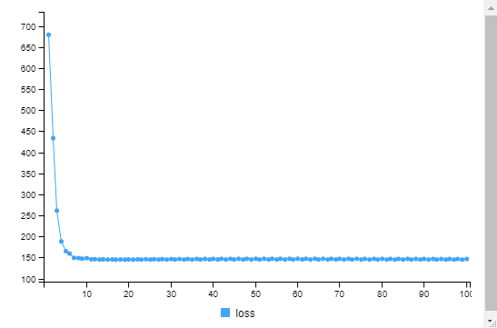

Função de perda

Uma vez que a rede foi implementada no Keras vamos comparar o **tempo computacional** e o **custo** das duas implementações **no conjunto de teste**.

Quanto ao tempo de computação, o algoritmo de de gradiente descendente da lista 1 levou

```r
library(tictoc)

######################################################
## Implementação da Lista 1
######################################################
X <- X_teste
Y <- Y_teste
theta_0 <- c(0, 0, 0, 0, 0, 0, 0, 0, 0)
n <- 100 # Número de iterações
tx_aprendisagem <- 0.1

componentes4 <- list(entrada = X,
                    observado = Y,
                    pesos_c1 = matrix(theta_0[1:4], nrow = 2, byrow = TRUE),
                    vies_c1 = matrix(theta_0[7:8], ncol = 2, nrow = dim(X)[1], byrow=TRUE),
                    pesos_cs = matrix(theta_0[5:6], nrow = 2, byrow = TRUE),
                    vies_cs = matrix(theta_0[9], ncol = 1, nrow = dim(Y)[1], byrow = TRUE),
                    camada_tl = matrix(rep(0,dim(X)[1]*dim(X)[2]),
                                       nrow=dim(X)[1], ncol=dim(X)[2],
                                       byrow = TRUE),
                    camada_tnl = matrix(rep(0,dim(X)[1]*dim(X)[2]),
                                        nrow=dim(X)[1], ncol=dim(X)[2],
                                        byrow = TRUE),
                    saida = matrix(rep(0,dim(Y)[1]), ncol=1)
                    )

##############################################
## Log do custo ao longo das iterações
##############################################
custo_evol_teste <- data.frame(
  iteracao = 1:n,
  cost = rep(0,n)
)
# Armazena os parâmetros de cada iteração
thetas <- data.frame()

tic("Lista1")
##############################################
## Gradiente descendente
##############################################
for (i in seq_len(n)){
    # Estimativa
    componentes4 <- previsao(componentes4)
    # Cálculo do custo
    custo_evol_teste$cost[i] <- custo(componentes4)
    # Atualização dos parâmetros
    thetas <- rbind(thetas, theta_0)
    theta_0 <- theta_0 - (tx_aprendisagem * gradiente(componentes4))
    componentes4$pesos_c1 <- matrix(theta_0[1:4], nrow = 2, byrow = TRUE)
    componentes4$vies_c1 <- matrix(theta_0[7:8], ncol = 2, nrow = dim(X_teste)[1], byrow=TRUE)
    componentes4$pesos_cs <- matrix(theta_0[5:6], nrow = 2, byrow = TRUE)
    componentes4$vies_cs <- matrix(theta_0[9], ncol = 1, nrow = dim(Y_teste)[1], byrow = TRUE)
  }
toc()
```

```
## Lista1: 0.53 sec elapsed
```

```r
tic("Keras")
Lista1 %>% fit(x = X_trein,
                   y = Y_trein,
                   epochs=100,
                   batch_size = dim(X_trein)[1], # full gradient descend
                   callbacks = callback_early_stopping(monitor = "loss",
                                                       patience = 200,
                                                       restore_best_weights = TRUE),
                   verbose = 0)
toc()
```

```
## Keras: 0.63 sec elapsed
```

Quanto ao custo temos que:

```r
custo_evol_testek <- data.frame(
  iteracao = 1:n,
  cost = rep(0,n)
)

custo_evol_testek$cost <- fit(Lista1, x = X_trein,
                   y = Y_trein,
                   epochs=100,
                   batch_size = dim(X_trein)[1], # full gradient descend
                   callbacks = callback_early_stopping(monitor = "loss",
                                                       patience = 200,
                                                       restore_best_weights = TRUE),
                   verbose = 0)$metrics$loss


cbind(c("Lista1","Keras"), rbind(
custo_evol_teste[which.min(custo_evol_teste$cost),],
custo_evol_testek[which.min(custo_evol_testek$cost),]))
```

```
##    c("Lista1", "Keras") iteracao     cost
## 19               Lista1       19 144.2809
## 11                Keras       11 145.0549
```

## 6. Identificar a rede com melhor ajuste

Nessa etapa se busca ajustar a rede com melhor ajuste tendo liberdade para alterar a arquitetura que foi definida na Lista 1.

Foram testadas várias arquiteturas com menos e mais camadas, mas a rede implementada abaixo é a que conseguiu o menor MSE.

```r
rm(Lista2)
set.seed(92021)

Lista2 <- keras_model_sequential()

Lista2 %>%
          layer_dense(input_shape = 2,
                       units = 6,
                       use_bias = TRUE,
                       activation = "tanh",
                       kernel_initializer = 'random_normal',
                       bias_initializer = 'random_normal' ) %>%
          layer_dense(units = 4,
                       use_bias = TRUE,
                       activation = "relu",
                       kernel_initializer = 'random_normal',
                       bias_initializer = 'random_normal' ) %>%
          layer_dense(units = 5,
                       use_bias = TRUE,
                       activation = "sigmoid",
                       kernel_initializer = 'random_normal',
                       bias_initializer = 'random_normal' ) %>%
          layer_dense(units = 3,
                       use_bias = TRUE,
                       activation = "softsign",
                       kernel_initializer = 'random_normal',
                       bias_initializer = 'random_normal' ) %>%
          layer_dense(units = 1,
                       use_bias = TRUE,
                       activation = "linear",
                       kernel_initializer = 'random_normal',
                       bias_initializer = 'random_normal')

summary(Lista2)
```

```
## Model: "sequential_1"
## ________________________________________________________________________________
## Layer (type)                        Output Shape                    Param #
## ================================================================================
## dense_6 (Dense)                     (None, 6)                       18
## ________________________________________________________________________________
## dense_5 (Dense)                     (None, 4)                       28
## ________________________________________________________________________________
## dense_4 (Dense)                     (None, 5)                       25
## ________________________________________________________________________________
## dense_3 (Dense)                     (None, 3)                       18
## ________________________________________________________________________________
## dense_2 (Dense)                     (None, 1)                       4
## ================================================================================
## Total params: 93
## Trainable params: 93
## Non-trainable params: 0
## ________________________________________________________________________________
```

```r
Lista2 %>% compile(loss = "mse",
                   optimizer = optimizer_sgd(learning_rate = 0.1))

Lista2 %>% fit(x = X_trein,
               y = Y_trein,
               epochs=200,
               validation_data = list(X_teste, Y_teste),
               batch_size = dim(X_trein)[1], # full gradient descend
               callbacks = callback_early_stopping(monitor = "loss",
                                                   patience = 50,
                                                   restore_best_weights = TRUE),
               verbose = 0)

comp_keras <- fit(Lista2, x = X_trein,
                   y = Y_trein,
                   epochs=100,
                   batch_size = dim(X_trein)[1], # full gradient descend
                   callbacks = callback_early_stopping(monitor = "loss",
                                                       patience = 200,
                                                       restore_best_weights = TRUE),
                   verbose = 0)

min(comp_keras$metrics$loss)
```

```
## [1] 73.05014
```

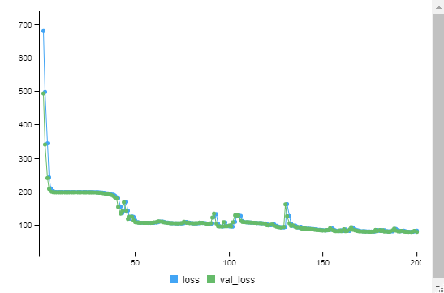

Função de perda

## 7. Gráfico do valor previsto x valor observado (Conjunto de Teste)

Esta seção faz a representação gráfica dos valores previstos com a “melhor rede” ajustada no Keras (`Lista2`) e os valores efetivamente observados no conjunto de teste.

Nota-se que o gráfico é muito menos “poluído” que o obtido no item h da Lista 1 devido ao melhor ajuste da previsão.

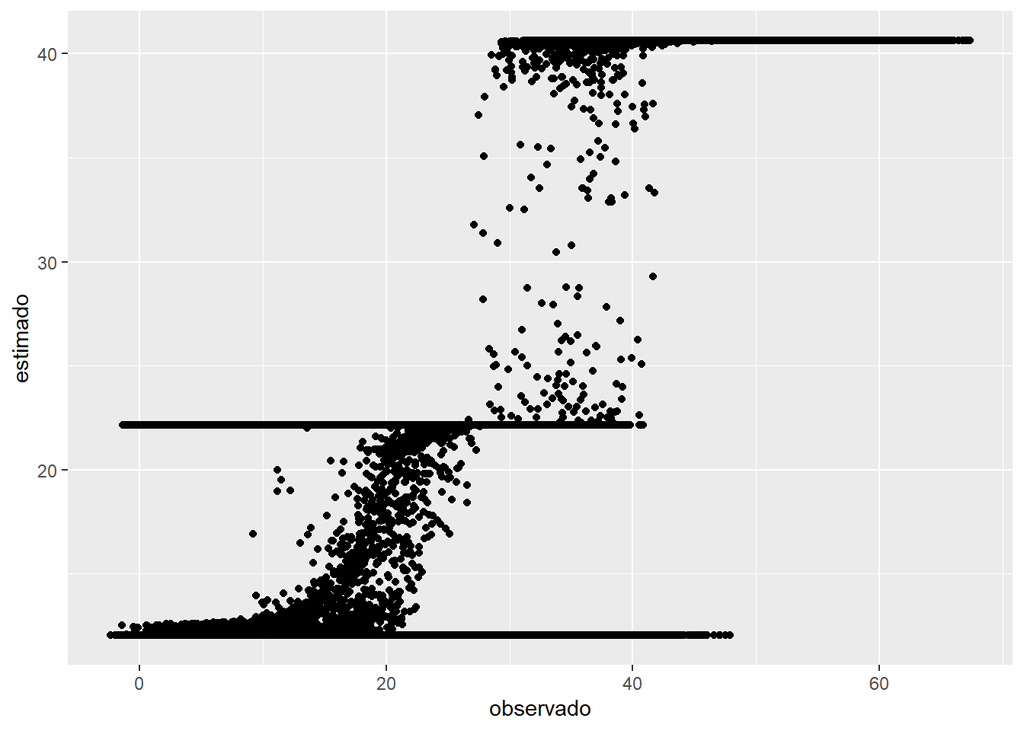

```r
estimado <- predict(Lista2, X_teste, verbose = 0)

grafico <- as_tibble(Y_teste) %>%
                rename_all(~ c("observado")) %>%
                mutate(estimado = estimado)

ggplot(data = grafico, aes(x=observado, y=estimado)) +
  geom_point()
```

## 8. Previsão para X = [1,1]

Nesta seção usamos a função de previsão do Keras para obter $\hat{y}$ quando os valores de entrada são $X=[1,1]$.

```r
predict(Lista2, matrix(c(1,1), ncol=2), verbose = 0)
```

```
##          [,1]
## [1,] 12.02467
```

## 9. Superfície real e estimada

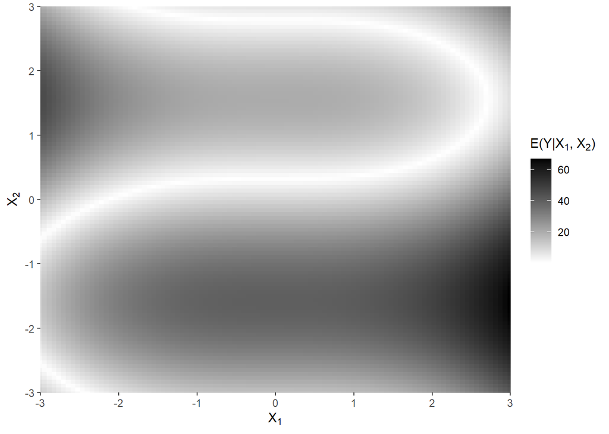

```r
par(mfrow=c(2,1))

n <- 100
x1 <- seq(-3, 3, length.out=n)
x2 <- seq(-3, 3, length.out=n)
dados.grid <- as_tibble(expand.grid(x1, x2)) %>%
rename_all(~ c("x1", "x2")) %>%
mutate(mu=abs(x1^3 - 30*sin(x2) + 10))
ggplot(dados.grid, aes(x=x1, y=x2)) +
geom_point(aes(colour=mu), size=2, shape=15) +
  coord_cartesian(expand=F) +
  scale_colour_gradient(low="white",
  high="black",
  name=TeX("E(Y|X_1, X_2)")) +
  xlab(TeX("X_1")) + ylab(TeX("X_2"))
```

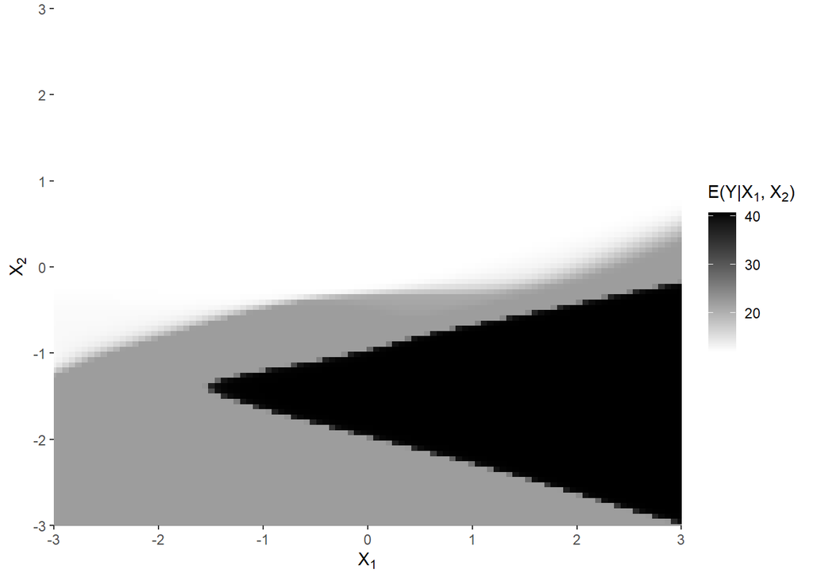

```r
dados.grid <- as_tibble(expand.grid(x1, x2)) %>%
rename_all(~ c("x1", "x2")) %>%
mutate(mu=predict(Lista2, as.matrix(cbind(x1,x2)), verbose = 0))
ggplot(dados.grid, aes(x=x1, y=x2)) +
geom_point(aes(colour=mu), size=2, shape=15) +
  coord_cartesian(expand=F) +
  scale_colour_gradient(low="white",
  high="black",
  name=TeX("E(Y|X_1, X_2)")) +
  xlab(TeX("X_1")) + ylab(TeX("X_2"))
```

## 10. Rede ajustada sobre os valores previstos

Nessa seção é feita a previsão para todas as observações utilizando a rede neural ajustada no Keras.

```r
# Previsão para todas as observações
Y_hat <- predict(Lista2, as.matrix(dados[,1:2], ncol=2), verbose = 0)
```

Em seguida é ajustada uma nova rede que busca modelar esses valores previstos.

Uma possível utilidade desse exercício seria simplificar a rede ajustada originalmente (`Lista2`). Se a rede original é uma boa aproximação aos valores observados e se essa segunda rede (mais simples) é uma boa aproximação a primeira então ela poderia ser utilizada no lugar daquela.

```r
rm(rede)
set.seed(92021)

rede <- keras_model_sequential()

rede %>%
          layer_dense(input_shape = 2,
                       units = 4,
                       use_bias = TRUE,
                       activation = "tanh",
                       kernel_initializer = 'random_normal',
                       bias_initializer = 'random_normal' ) %>%
          layer_dense(units = 2,
                       use_bias = TRUE,
                       activation = "relu",
                       kernel_initializer = 'random_normal',
                       bias_initializer = 'random_normal' ) %>%
          layer_dense(units = 2,
                       use_bias = TRUE,
                       activation = "sigmoid",
                       kernel_initializer = 'random_normal',
                       bias_initializer = 'random_normal' ) %>%
          layer_dense(units = 1,
                       use_bias = TRUE,
                       activation = "linear",
                       kernel_initializer = 'random_normal',
                       bias_initializer = 'random_normal')

summary(rede)
```

```
## Model: "sequential_2"
## ________________________________________________________________________________
## Layer (type)                        Output Shape                    Param #
## ================================================================================
## dense_10 (Dense)                    (None, 4)                       12
## ________________________________________________________________________________
## dense_9 (Dense)                     (None, 2)                       10
## ________________________________________________________________________________
## dense_8 (Dense)                     (None, 2)                       6
## ________________________________________________________________________________
## dense_7 (Dense)                     (None, 1)                       3
## ================================================================================
## Total params: 31
## Trainable params: 31
## Non-trainable params: 0
## ________________________________________________________________________________
```

```r
rede %>% compile(loss = "mse",
                   optimizer = optimizer_sgd(learning_rate = 0.1))

rede %>% fit(x = as.matrix(dados[,1:2], ncol=2),
               y = Y_hat,
               epochs=200,
               batch_size = dim(Y_hat)[1], # full gradient descend
               callbacks = callback_early_stopping(monitor = "loss",
                                                   patience = 50,
                                                   restore_best_weights = TRUE),
               verbose = 0)
```

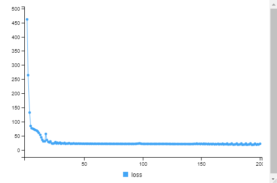

Função de perda

## 11. Recursos consultados

DAHAL, P. Dropout Layer - The unconventional regularization technique. Disponível em: http://deepnotes.io/dropout. Acesso em: 22/9/2021.

GOODFELLOW, I.; BENGIO, Y.; COURVILLE, A. Deep learning. Cambridge, Massachusetts: The MIT Press, 2016.

KRISTIADI, A. Implementing Dropout in Neural Net. Agustinus Kristiadi’s Blog. Disponível em: http://wiseodd.github.io/techblog/2016/06/25/dropout/. Acesso em: 22/9/2021.

LEWIS, N. D. C. Deep learning made easy with R: a gentle introduction for data science. Place of publication not identified: AusCov, 2016.